# From Probability to Profit: A Decision-Support System for Prescriptive Churn Management using COFINFAD

# Background

The Colombian financial technology (Fintech) sector has witnessed a paradigm shift toward digital-first banking, characterized by the rapid expansion of inclusive financial services. The [**COFINFAD** (Colombian Fintech Financial Analytics) dataset](https://data.mendeley.com/datasets/mhb4zn3258/1) reflects this landscape, capturing granular behavioral data across a diverse user base. While these platforms have successfully digitized traditional banking functions, the low barrier to entry for competitors has resulted in a highly volatile customer base. In this environment, the ability to analyze and anticipate customer behavior—ranging from app engagement patterns to sentiment metrics (NPS)—is no longer a competitive advantage but a fundamental requirement for institutional sustainability and **Customer Lifetime Value (CLV)** optimization.

# Problem Statement

Despite the availability of high-frequency behavioral data, the organization faces two critical challenges that threaten long-term profitability:

- **High-Value Attrition:** There is a documented trend of “Value Leakage,” where customers possessing high CLV are churned without prior strategic intervention. The absence of a prioritization framework means that high-stakes retention opportunities are often identified only post-attrition, leading to significant revenue loss.
- **Surface-Level Engagement:** Analysis reveals a “Feature Adoption Deficit,” where a substantial portion of the user base utilizes only foundational services (e.g., peer-to-peer transfers). This lack of **feature usage diversity** results in low “stickiness,” as users who do not integrate into the broader fintech ecosystem (investment, insurance, etc.) exhibit a higher propensity to churn when presented with minor external incentives.

# Project Motivation

The objective of this research is to develop a **prescriptive analytics framework** that transitions churn management from passive observation to proactive intervention. By systematically identifying high-value customers with an elevated propensity for attrition, the project seeks to isolate specific, **actionable drivers** of dissatisfaction. Through this framework, the organization can simulate targeted retention strategies—such as fee adjustments or service enhancements—to effectively mitigate risk, preserve CLV, and foster long-term institutional loyalty.

# Methodology and Analytical Approach

## Predictive modeling

### Model Development and Selection

The analytical framework for this project follows a supervised learning approach to estimate **customer churn probability**. Two high-performance ensemble algorithms were selected for comparative analysis: **Random Forest** and **eXtreme Gradient Boosting (XGBoost)**. These models were chosen for their ability to handle non-linear relationships and high-dimensional data, which are characteristic of the fintech behavioral metrics found in the COFINFAD dataset.

### Hyperparameter Optimization and Validation

To ensure model robustness and prevent overfitting, a systematic **grid search** approach was employed for hyperparameter tuning. The tuning process focused on optimizing critical parameters such as tree depth, learning rate, and feature sampling ratios.

To validate the generalizability of the models, **k-fold cross-validation** was implemented. This process involves partitioning the training data into multiple folds to ensure that the model performance is consistent across different subsets of the data, providing a more reliable estimate of how the model will perform on unseen customer profiles.

### Performance Evaluation Metrics

The performance of the candidate models was evaluated using three primary regression metrics to identify the “Best Fit” model:

- **Root Mean Square Error (RMSE):** To penalize larger prediction errors, ensuring the model remains accurate for high-risk profiles.
- **Mean Absolute Error (MAE):** To provide a clear measure of the average magnitude of the prediction errors in terms of probability units.
- **R-Squared:** To determine the proportion of variance in churn behavior explained by the independent variables.

### Feature Importance and Interpretability

Upon selecting the optimal model based on the lowest error metrics and highest R-Squared, the framework transitions to identifying the **Top 10 Predictor Variables**. By calculating **Feature Importance Scores**, the project isolates the primary drivers of churn. This prioritized list serves as the foundation for the diagnostic phase of the dashboard, allowing the organization to focus its retention efforts on the most influential behavioral and financial triggers.

# Data Visualisation Methods

## Predictive Modeling

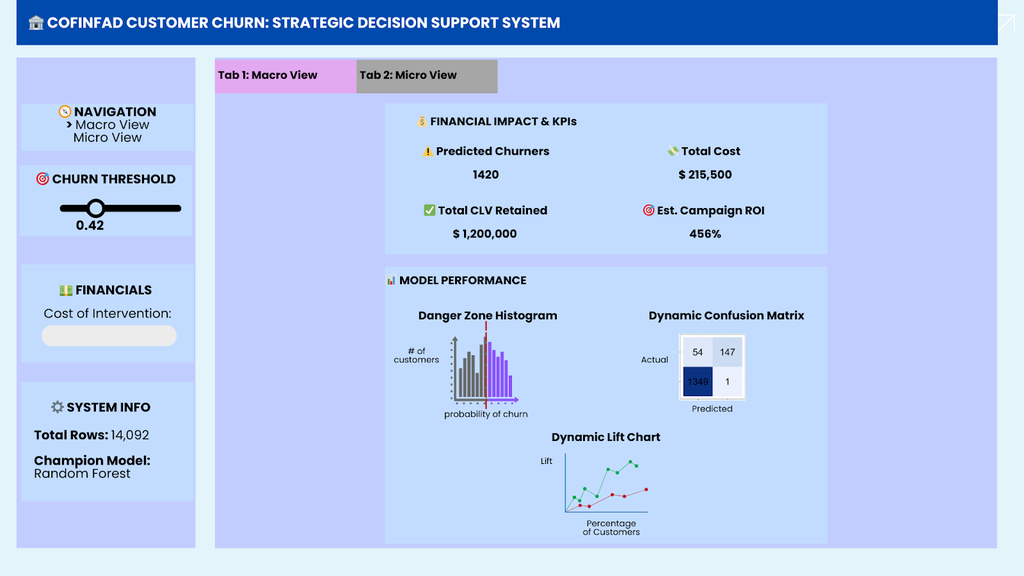

### Tab 1: Macro View (Strategic Risk Assessment)

The Macro View is designed to provide executive stakeholders with a comprehensive overview of the portfolio’s risk profile. The primary visualization methods include:

- **Risk Distribution Histogram:** This utilizes a frequency distribution of predicted churn probabilities to visualize the density of at-risk customers. It incorporates a **Dynamic Threshold Overlay**, allowing users to visually segment the population into “Safe” and “Actionable” zones based on varying risk tolerances.
- **Dynamic Confusion Matrix:** This visualization translates model performance into operational impact. It shifts in real-time as the threshold is adjusted, illustrating the trade-off between false positives (cost of unnecessary intervention) and false negatives (unidentified revenue loss).
- **Cumulative Lift Chart:** This method is employed to demonstrate model efficacy. By plotting the cumulative percentage of churners captured against the percentage of the population targeted, it identifies the “Point of Diminishing Returns,” ensuring efficient resource allocation.

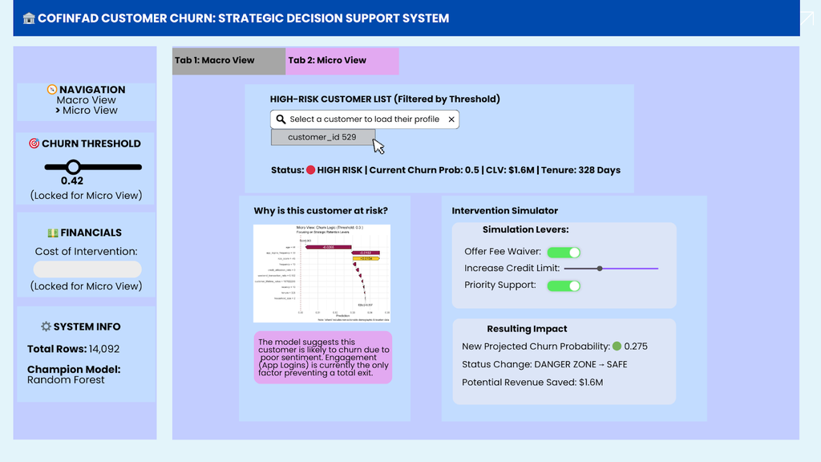

### Tab 2: Micro View (Diagnostic and Prescriptive Analysis)

The Micro View shifts the focus to individual-level diagnostics, allowing account managers to investigate specific high-value profiles. The primary visualization methods include:

- **SHAP Waterfall Chart:** This chart is the core diagnostic tool, used to deconstruct a single customer’s churn probability. It visualizes the “Tug-of-War” between predictors, showing exactly how much specific variables (e.g., nps_score, app_logins_frequency) contribute to or mitigate the final risk score. This provides transparency into the model’s reasoning without requiring technical expertise.
- **What-If Simulation Levers:** This interactive interface utilizes input controls (sliders and toggles) to allow users to manipulate customer features. It provides a real-time visual update of the projected churn probability, enabling the simulation of specific retention strategies—such as fee waivers or credit limit increases—to determine their impact on risk reduction.
- **Prioritized Feature View:** To minimize cognitive load, this section is restricted to the **Top 10 Strategic Variables**. This ensures that the visualization remains focused on actionable behavioral levers rather than non-modifiable demographic data.

# R Shiny Packages

- `tidyverse`: A collection of fundamental R packages designed for data science, covering everything from data cleaning to creating static statistical graphs.
- `naniar`: Provides a suite of functions to tidy, visualize, and analyze missing data (NAs)
- `skimr`: A tool for quick data assessment. It produces a “skim” of a dataframe, providing summary statistics (mean, SD, quantiles) and tiny inline histograms (sparklines) for a fast overview of distributions.
- `knitr`: The engine behind dynamic report generation in R. It integrates R code into Markdown, LaTeX, or HTML documents, allowing you to “knit” your analysis into a finished report.
- `dplyr`: It’s the package for filtering, selecting, mutating, and summarizing dataframes using a clean, readable syntax.
- `kableExtra:` An extension for knitr::kable() that provides advanced styling options for HTML and PDF tables, such as striped rows, hover effects, and complex headers.
- `patchwork`: Makes combining multiple ggplots incredibly simple.
- `corrplot:` A graphical display of a correlation matrix. It helps you quickly identify patterns and strengths of relationships between variables using colors and shapes.
- `tidymodels:` A “meta-package” (like the tidyverse) designed for modeling and machine learning. It provides a consistent framework for preprocessing, training, and validating models.
- `ranger:` A fast implementation of Random Forests. It is highly memory-efficient and particularly well-suited for high-dimensional data.
- `xgboost:` An interface for Extreme Gradient Boosting. It’s a powerful, scalable library used for gradient-boosted decision trees, often favored in data science competitions for its speed and performance.
- `vip:` Stands for Variable Importance Plots. It extracts and visualizes the importance of features in various machine learning models, helping you understand which variables are driving your model’s predictions.
- `car:` provides advanced statistical tests and diagnostic tools—such as the vif() function—to evaluate, troubleshoot, and refine regression models.
- `rsample`: provides the tools to split your data into training and testing sets, as well as create resampled data like cross-validation folds.
- `tune`: helps optimize your machine learning models by testing and finding the best possible hyperparameter values.
- `parsnip`: gives a single, standardized interface to build and fit various types of machine learning models
- `workflows`: simplifies your coding pipeline by bundling your data pre-processing steps and the parsnip model into one cohesive object that can be trained and tested together.
- `yardstick`: provides a consistent, tidy interface for calculating model performance metrics